# 444585_hw1

Author: Santiago Matallana

Re: Machine Learning for Public Policy - Assignment 1

Created: 2016-04-01

```python
#Requirements
import pandas as pd
import matplotlib.pyplot as plt
%matplotlib inline
plt.rcParams["figure.figsize"] = [18.0, 8.0]
plt.style.use('ggplot')
import requests
import os
```

# Problem A

### 1. The first task is to load the file and generate summary statistics for each field as well as probability distributions or histograms. The summary statistics should include mean, median, mode, standard deviation, as well as the number of missing values for each field.

```python
# Read csv file
records = pd.read_csv('mock_student_data.csv')
records.head()
```

|  | ID | First_name | Last_name | State | Gender | Age | GPA | Days_missed | Graduated |
| --- | --- | --- | --- | --- | --- | --- | --- | --- | --- |
| 0 | 1 | Wayne | Boyd | Florida | Male | 19 | NaN | 9 | Yes |
| 1 | 2 | Ann | Matthews | Pennsylvania | Female | 18 | 3 | NaN | Yes |
| 2 | 3 | George | Matthews | Texas | NaN | 17 | NaN | 10 | Yes |
| 3 | 4 | Jerry | Ramos | California | Male | 15 | 2 | 28 | No |
| 4 | 5 | Andrea | Carroll | North Carolina | Female | NaN | 2 | 29 | No |

```python
# Summary statistics
summary = records.describe(include='all')
summary
```

|  | ID | First_name | Last_name | State | Gender | Age | GPA | Days_missed | Graduated |
| --- | --- | --- | --- | --- | --- | --- | --- | --- | --- |
| count | 1000.000000 | 1000 | 1000 | 884 | 774 | 771.000000 | 779.000000 | 808.000000 | 1000 |
| unique | NaN | 200 | 244 | 49 | 2 | NaN | NaN | NaN | 2 |
| top | NaN | Amy | Ross | Texas | Female | NaN | NaN | NaN | Yes |
| freq | NaN | 12 | 13 | 97 | 398 | NaN | NaN | NaN | 593 |
| mean | 500.500000 | NaN | NaN | NaN | NaN | 16.996109 | 2.988447 | 18.011139 | NaN |
| std | 288.819436 | NaN | NaN | NaN | NaN | 1.458067 | 0.818249 | 9.629371 | NaN |
| min | 1.000000 | NaN | NaN | NaN | NaN | 15.000000 | 2.000000 | 2.000000 | NaN |
| 25% | 250.750000 | NaN | NaN | NaN | NaN | 16.000000 | 2.000000 | 9.000000 | NaN |
| 50% | 500.500000 | NaN | NaN | NaN | NaN | 17.000000 | 3.000000 | 18.000000 | NaN |
| 75% | 750.250000 | NaN | NaN | NaN | NaN | 18.000000 | 4.000000 | 27.000000 | NaN |
| max | 1000.000000 | NaN | NaN | NaN | NaN | 19.000000 | 4.000000 | 34.000000 | NaN |

```python
# Add row with number of missing values
summary.loc['missing'] = len(records) - summary.loc['count']
summary
```

|  | ID | First_name | Last_name | State | Gender | Age | GPA | Days_missed | Graduated |
| --- | --- | --- | --- | --- | --- | --- | --- | --- | --- |
| count | 1000.000000 | 1000 | 1000 | 884 | 774 | 771.000000 | 779.000000 | 808.000000 | 1000 |
| unique | NaN | 200 | 244 | 49 | 2 | NaN | NaN | NaN | 2 |
| top | NaN | Amy | Ross | Texas | Female | NaN | NaN | NaN | Yes |
| freq | NaN | 12 | 13 | 97 | 398 | NaN | NaN | NaN | 593 |
| mean | 500.500000 | NaN | NaN | NaN | NaN | 16.996109 | 2.988447 | 18.011139 | NaN |
| std | 288.819436 | NaN | NaN | NaN | NaN | 1.458067 | 0.818249 | 9.629371 | NaN |
| min | 1.000000 | NaN | NaN | NaN | NaN | 15.000000 | 2.000000 | 2.000000 | NaN |
| 25% | 250.750000 | NaN | NaN | NaN | NaN | 16.000000 | 2.000000 | 9.000000 | NaN |
| 50% | 500.500000 | NaN | NaN | NaN | NaN | 17.000000 | 3.000000 | 18.000000 | NaN |
| 75% | 750.250000 | NaN | NaN | NaN | NaN | 18.000000 | 4.000000 | 27.000000 | NaN |
| max | 1000.000000 | NaN | NaN | NaN | NaN | 19.000000 | 4.000000 | 34.000000 | NaN |
| missing | 0.000000 | 0 | 0 | 116 | 226 | 229.000000 | 221.000000 | 192.000000 | 0 |

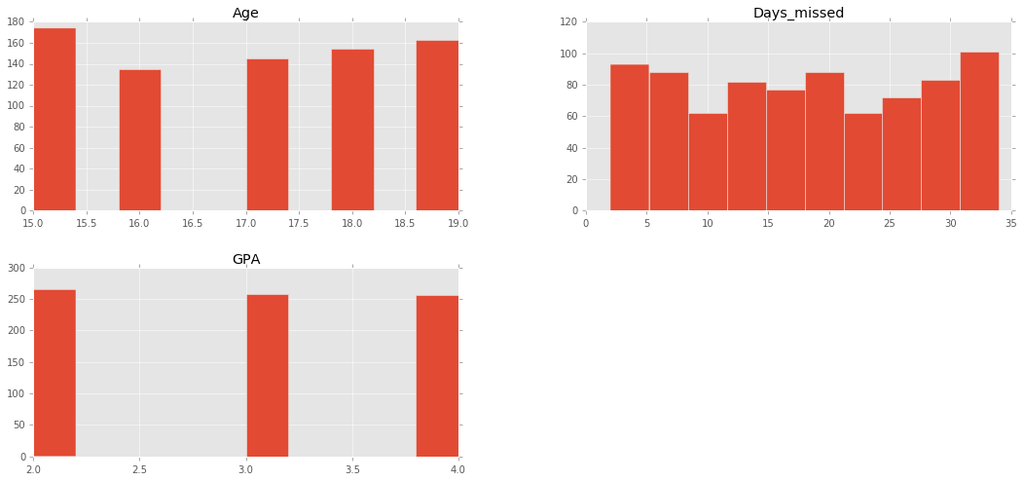

```python
# Histograms
pd.DataFrame(records.loc[:, records.columns != 'ID']).hist();
plt.savefig('images/histograms.png')
```

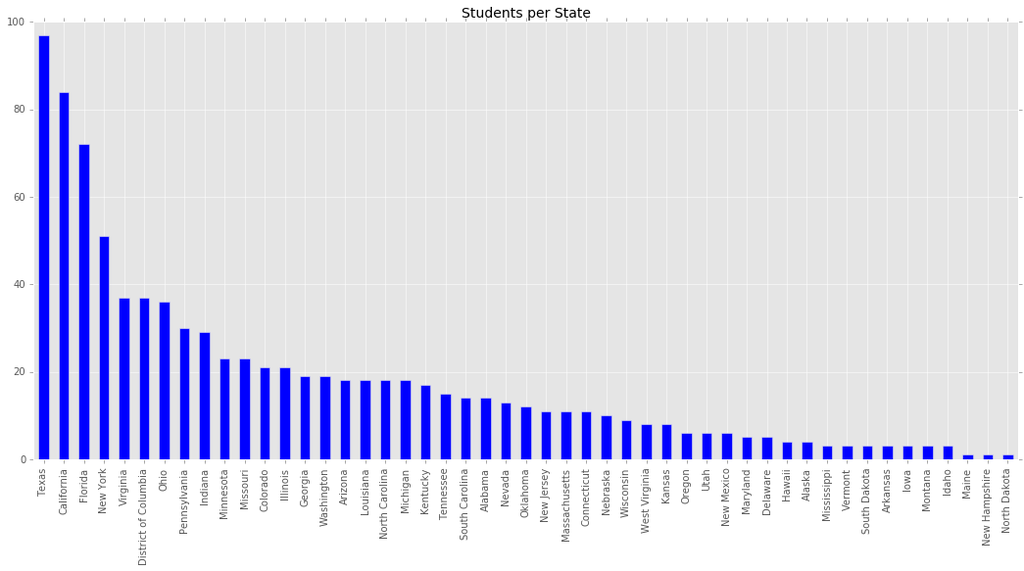

```python
# Bar plot of States
records['State'].value_counts().plot.bar()
plt.title("Students per State", fontdict={'fontsize': 14});
plt.savefig('images/barplot_state.png')
```

```python
# Include missing values in gender variable
gender = records['Gender'].value_counts()
gender['Missing'] = len(records) - gender['Male'] - gender['Female']
gender
```

```
Female     398
Male       376
Missing    226
Name: Gender, dtype: int64
```

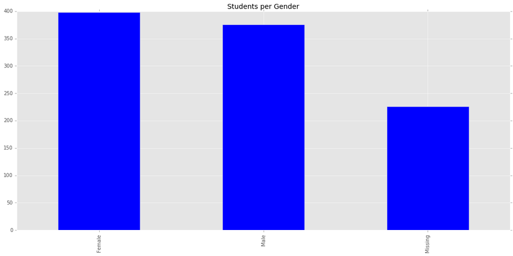

```python
# Bar plot of gender
gender.plot.bar()
plt.title("Students per Gender", fontdict={'fontsize': 14});
plt.savefig('images/barplot_gender.png')
```

### 2. You will notice that a lot of students are missing gender values . Your task is to infer the gender of the student based on their name. Please use the API at www.genderize.io to infer the gender of each student and generate a new data file.

```python
def get_gender(name):
    '''
    Returns gender from name string, using API at www.genderize.io
    Requires requests module
    '''
    urlprefix = 'https://api.genderize.io/?name='  # Define url prefix
    r = requests.get(urlprefix + name.lower())
    return r.json()['gender']
```

```python
# Apply 'get_gender' function to all names with missing gender
gender = records[records['Gender'].isnull()]['First_name'].apply(get_gender)
```

```python
# Replace missing gender values
records.loc[records['Gender'].isnull(), 'Gender'] = gender
```

```python
# Summary statistics
summary = records.describe(include='all')
summary
```

|  | ID | First_name | Last_name | State | Gender | Age | GPA | Days_missed | Graduated |
| --- | --- | --- | --- | --- | --- | --- | --- | --- | --- |
| count | 1000.000000 | 1000 | 1000 | 884 | 1000 | 771.000000 | 779.000000 | 808.000000 | 1000 |
| unique | NaN | 200 | 244 | 49 | 4 | NaN | NaN | NaN | 2 |
| top | NaN | Amy | Ross | Texas | Female | NaN | NaN | NaN | Yes |
| freq | NaN | 12 | 13 | 97 | 398 | NaN | NaN | NaN | 593 |
| mean | 500.500000 | NaN | NaN | NaN | NaN | 16.996109 | 2.988447 | 18.011139 | NaN |
| std | 288.819436 | NaN | NaN | NaN | NaN | 1.458067 | 0.818249 | 9.629371 | NaN |
| min | 1.000000 | NaN | NaN | NaN | NaN | 15.000000 | 2.000000 | 2.000000 | NaN |
| 25% | 250.750000 | NaN | NaN | NaN | NaN | 16.000000 | 2.000000 | 9.000000 | NaN |
| 50% | 500.500000 | NaN | NaN | NaN | NaN | 17.000000 | 3.000000 | 18.000000 | NaN |
| 75% | 750.250000 | NaN | NaN | NaN | NaN | 18.000000 | 4.000000 | 27.000000 | NaN |
| max | 1000.000000 | NaN | NaN | NaN | NaN | 19.000000 | 4.000000 | 34.000000 | NaN |

```python
# Capitalize gender column strings
records['Gender'] = records['Gender'].apply(str.capitalize)
```

```python
# Create directory for new data files
if not os.path.exists('new_data_files'):
    os.mkdir('new_data_files')
# Generate a new data file
records.to_csv('new_data_files/Q2.csv')
```

### 3. You will also notice that some of the other attributes are missing. Your task is to fill in the missing values for Age, GPA, and Days_missed using the following approaches:

### A. Fill in missing values with the mean of the values for that attribute.

```python
# Create copy of dataframe
records2 = records.copy()
```

```python
# Fill in missing values of 'Age' with its mean
records2.loc[records2['Age'].isnull(), 'Age'] = records2['Age'].mean()

# Fill in missing values of 'GPA' with its mean
records2.loc[records2['GPA'].isnull(), 'GPA'] = records2['GPA'].mean()

# Fill in missing values of 'Days_missed' with its mean
records2.loc[records2['Days_missed'].isnull(), 'Days_missed'] = records2['Days_missed'].mean()
```

```python
pd.DataFrame(records2.describe().loc['mean', ['Age', 'GPA', 'Days_missed']])
```

|  | mean |
| --- | --- |
| Age | 16.996109 |
| GPA | 2.988447 |
| Days_missed | 18.011139 |

```python
# Create directory for new data files
if not os.path.exists('new_data_files'):
    os.mkdir('new_data_files')
# Generate a new data file
records2.to_csv('new_data_files/Q3A.csv')
```

### B. Fill in missing values with a class-conditional mean (where the class is whether they graduated or not).

```python
# Create copy of dataframe
records3 = records.copy()
```

Age

```python
# Age mean for graduates
grad_age_mean = records3[records3['Graduated'] == 'Yes']['Age'].mean()
grad_age_mean
```

```
16.958874458874458
```

```python
# Age mean for non-graduates
non_grad_age_mean = records3[records3['Graduated'] == 'No']['Age'].mean()
non_grad_age_mean
```

```
17.051779935275082
```

```python
# Fill in missing values of 'Age' with its class-conditional mean (graduated or not)
records3.loc[(records3['Graduated'] == 'Yes') & (records3['Age'].isnull()), 'Age'] = grad_age_mean
records3.loc[(records3['Graduated'] == 'No') & (records3['Age'].isnull()), 'Age'] = non_grad_age_mean
```

GPA

```python
# GPA mean for graduates
grad_GPA_mean = records3[records3['Graduated'] == 'Yes']['GPA'].mean()
grad_GPA_mean
```

```
3.5053763440860215
```

```python
# GPA mean for non-graduates
non_grad_GPA_mean = records3[records3['Graduated'] == 'No']['GPA'].mean()
non_grad_GPA_mean
```

```
2.515970515970516
```

```python
# Fill in missing values of 'GPA' with its class-conditional mean (graduated or not)
records3.loc[(records3['Graduated'] == 'Yes') & (records3['GPA'].isnull()), 'GPA'] = grad_GPA_mean
records3.loc[(records3['Graduated'] == 'No') & (records3['GPA'].isnull()), 'GPA'] = non_grad_GPA_mean
```

Days_missed

```python
# Days_missed mean for graduates
grad_days_mean = records3[records3['Graduated'] == 'Yes']['Days_missed'].mean()
grad_days_mean
```

```
16.77556109725686
```

```python
# Days_missed mean for non-graduates
non_grad_days_mean = records3[records3['Graduated'] == 'No']['Days_missed'].mean()
non_grad_days_mean
```

```
19.22850122850123
```

```python
# Fill in missing values of 'Days_missed' with its class-conditional mean (graduated or not)
records3.loc[(records3['Graduated'] == 'Yes') & (records3['Days_missed'].isnull()), 'Days_missed'] = grad_days_mean
records3.loc[(records3['Graduated'] == 'No') & (records3['Days_missed'].isnull()), 'Days_missed'] = non_grad_days_mean
```

```python
pd.DataFrame(records3.describe().loc['mean', ['Age', 'GPA', 'Days_missed']])
```

|  | mean |
| --- | --- |
| Age | 16.996687 |
| GPA | 3.102688 |
| Days_missed | 17.773908 |

```python
# Create directory for new data files
if not os.path.exists('new_data_files'):
    os.mkdir('new_data_files')
# Generate a new data file
records3.to_csv('new_data_files/Q3B.csv')
```

### C. Is there a better, more appropriate method for filling in the missing values? If yes, describe and implement it.

```python
# Create copy of dataframe
records4 = records.copy()
```

**Age**: better to fill in with class-conditional means using combinations of:

- Graduated {Yes, No}
- Gender {Male, Female}

```python
# Define classes (4 combinations)
age1 = records4[(records4['Graduated'] == 'Yes') & (records4['Gender'] == 'Male')]
age2 = records4[(records4['Graduated'] == 'Yes') & (records4['Gender'] == 'Female')]
age3 = records4[(records4['Graduated'] == 'No') & (records4['Gender'] == 'Male')]
age4 = records4[(records4['Graduated'] == 'No') & (records4['Gender'] == 'Female')]
```

```python
# Define class-conditional means
age1_mean = records4[(records4['Graduated'] == 'Yes') & (records4['Gender'] == 'Male')]['Age'].mean()
age2_mean = records4[(records4['Graduated'] == 'Yes') & (records4['Gender'] == 'Female')]['Age'].mean()
age3_mean = records4[(records4['Graduated'] == 'No') & (records4['Gender'] == 'Male')]['Age'].mean()
age4_mean = records4[(records4['Graduated'] == 'No') & (records4['Gender'] == 'Female')]['Age'].mean()
age1_mean, age2_mean, age3_mean, age4_mean
```

```
(16.948837209302326,
 16.967611336032387,
 17.136363636363637,
 16.967741935483872)
```

```python
# Fill in missing values
records4.loc[age1[age1['Age'].isnull()].index, 'Age'] = age1_mean
records4.loc[age2[age2['Age'].isnull()].index, 'Age'] = age2_mean
records4.loc[age3[age3['Age'].isnull()].index, 'Age'] = age3_mean
records4.loc[age4[age4['Age'].isnull()].index, 'Age'] = age4_mean
```

**GPA**: better to fill in with class-conditional means using combinations of:

- Graduated {Yes, No}
- Gender {Male, Female}
- Days_missed, by quartiles: [2,9), [9,18), [18,27), [27,34)

```python
# Define classes (16 combinations)
GPA1 = records4[(records4['Graduated'] == 'Yes') & (records4['Gender'] == 'Male') & (records4['Days_missed'] >= 2) & \
                (records4['Days_missed'] < 9)]
GPA2 = records4[(records4['Graduated'] == 'Yes') & (records4['Gender'] == 'Male') & (records4['Days_missed'] >= 9) & \
                (records4['Days_missed'] < 18)]
GPA3 = records4[(records4['Graduated'] == 'Yes') & (records4['Gender'] == 'Male') & (records4['Days_missed'] >= 18) & \
                (records4['Days_missed'] < 27)]
GPA4 = records4[(records4['Graduated'] == 'Yes') & (records4['Gender'] == 'Male') & (records4['Days_missed'] >= 27) & \
                (records4['Days_missed'] < 34)]
GPA5 = records4[(records4['Graduated'] == 'Yes') & (records4['Gender'] == 'Female') & (records4['Days_missed'] >= 2) & \
                (records4['Days_missed'] < 9)]
GPA6 = records4[(records4['Graduated'] == 'Yes') & (records4['Gender'] == 'Female') & (records4['Days_missed'] >= 9) & \
                (records4['Days_missed'] < 18)]
GPA7 = records4[(records4['Graduated'] == 'Yes') & (records4['Gender'] == 'Female') & (records4['Days_missed'] >= 18) & \
                (records4['Days_missed'] < 27)]
GPA8 = records4[(records4['Graduated'] == 'Yes') & (records4['Gender'] == 'Female') & (records4['Days_missed'] >= 27) & \
                (records4['Days_missed'] < 34)]
GPA9 = records4[(records4['Graduated'] == 'No') & (records4['Gender'] == 'Male') & (records4['Days_missed'] >= 2) & \
                (records4['Days_missed'] < 9)]
GPA10 = records4[(records4['Graduated'] == 'No') & (records4['Gender'] == 'Male') & (records4['Days_missed'] >= 9) & \
                (records4['Days_missed'] < 18)]
GPA11 = records4[(records4['Graduated'] == 'No') & (records4['Gender'] == 'Male') & (records4['Days_missed'] >= 18) & \
                (records4['Days_missed'] < 27)]
GPA12 = records4[(records4['Graduated'] == 'No') & (records4['Gender'] == 'Male') & (records4['Days_missed'] >= 27) & \
                (records4['Days_missed'] < 34)]
GPA13 = records4[(records4['Graduated'] == 'No') & (records4['Gender'] == 'Female') & (records4['Days_missed'] >= 2) & \
                (records4['Days_missed'] < 9)]
GPA14 = records4[(records4['Graduated'] == 'No') & (records4['Gender'] == 'Female') & (records4['Days_missed'] >= 9) & \
                (records4['Days_missed'] < 18)]
GPA15 = records4[(records4['Graduated'] == 'No') & (records4['Gender'] == 'Female') & (records4['Days_missed'] >= 18) & \
                (records4['Days_missed'] < 27)]
GPA16 = records4[(records4['Graduated'] == 'No') & (records4['Gender'] == 'Female') & (records4['Days_missed'] >= 27) & \
                (records4['Days_missed'] < 34)]
```

```python
# Define class-conditional means
GPA1_mean = records4[(records4['Graduated'] == 'Yes') & (records4['Gender'] == 'Male') & (records4['Days_missed'] >= 2) & \
                (records4['Days_missed'] < 9)]['GPA'].mean()
GPA2_mean = records4[(records4['Graduated'] == 'Yes') & (records4['Gender'] == 'Male') & (records4['Days_missed'] >= 9) & \
                (records4['Days_missed'] < 18)]['GPA'].mean()
GPA3_mean = records4[(records4['Graduated'] == 'Yes') & (records4['Gender'] == 'Male') & (records4['Days_missed'] >= 18) & \
                (records4['Days_missed'] < 27)]['GPA'].mean()
GPA4_mean = records4[(records4['Graduated'] == 'Yes') & (records4['Gender'] == 'Male') & (records4['Days_missed'] >= 27) & \
                (records4['Days_missed'] < 34)]['GPA'].mean()
GPA5_mean = records4[(records4['Graduated'] == 'Yes') & (records4['Gender'] == 'Female') & (records4['Days_missed'] >= 2) & \
                (records4['Days_missed'] < 9)]['GPA'].mean()
GPA6_mean = records4[(records4['Graduated'] == 'Yes') & (records4['Gender'] == 'Female') & (records4['Days_missed'] >= 9) & \
                (records4['Days_missed'] < 18)]['GPA'].mean()
GPA7_mean = records4[(records4['Graduated'] == 'Yes') & (records4['Gender'] == 'Female') & (records4['Days_missed'] >= 18) & \
                (records4['Days_missed'] < 27)]['GPA'].mean()
GPA8_mean = records4[(records4['Graduated'] == 'Yes') & (records4['Gender'] == 'Female') & (records4['Days_missed'] >= 27) & \
                (records4['Days_missed'] < 34)]['GPA'].mean()
GPA9_mean = records4[(records4['Graduated'] == 'No') & (records4['Gender'] == 'Male') & (records4['Days_missed'] >= 2) & \
                (records4['Days_missed'] < 9)]['GPA'].mean()
GPA10_mean = records4[(records4['Graduated'] == 'No') & (records4['Gender'] == 'Male') & (records4['Days_missed'] >= 9) & \
                (records4['Days_missed'] < 18)]['GPA'].mean()
GPA11_mean = records4[(records4['Graduated'] == 'No') & (records4['Gender'] == 'Male') & (records4['Days_missed'] >= 18) & \
                (records4['Days_missed'] < 27)]['GPA'].mean()
GPA12_mean = records4[(records4['Graduated'] == 'No') & (records4['Gender'] == 'Male') & (records4['Days_missed'] >= 27) & \
                (records4['Days_missed'] < 34)]['GPA'].mean()
GPA13_mean = records4[(records4['Graduated'] == 'No') & (records4['Gender'] == 'Female') & (records4['Days_missed'] >= 2) & \
                (records4['Days_missed'] < 9)]['GPA'].mean()
GPA14_mean = records4[(records4['Graduated'] == 'No') & (records4['Gender'] == 'Female') & (records4['Days_missed'] >= 9) & \
                (records4['Days_missed'] < 18)]['GPA'].mean()
GPA15_mean = records4[(records4['Graduated'] == 'No') & (records4['Gender'] == 'Female') & (records4['Days_missed'] >= 18) & \
                (records4['Days_missed'] < 27)]['GPA'].mean()
GPA16_mean = records4[(records4['Graduated'] == 'No') & (records4['Gender'] == 'Female') & (records4['Days_missed'] >= 27) & \
                (records4['Days_missed'] < 34)]['GPA'].mean()
GPA1_mean, GPA2_mean, GPA3_mean, GPA4_mean, GPA5_mean, GPA6_mean, GPA7_mean, GPA8_mean, GPA9_mean, GPA10_mean, GPA11_mean, \
    GPA12_mean, GPA13_mean, GPA14_mean, GPA15_mean, GPA16_mean
```

```
(3.5428571428571427,
 4.0,
 4.0,
 4.0,
 3.4285714285714284,
 4.0,
 4.0,
 4.0,
 2.5294117647058822,
 2.466666666666667,
 2.5833333333333335,
 2.5,
 2.4,
 2.5,
 2.5555555555555554,
 2.519230769230769)
```

```python
# Fill in missing values
records4.loc[GPA1[GPA1['GPA'].isnull()].index, 'GPA'] = GPA1_mean
records4.loc[GPA2[GPA2['GPA'].isnull()].index, 'GPA'] = GPA2_mean
records4.loc[GPA3[GPA3['GPA'].isnull()].index, 'GPA'] = GPA3_mean
records4.loc[GPA4[GPA4['GPA'].isnull()].index, 'GPA'] = GPA4_mean
records4.loc[GPA5[GPA5['GPA'].isnull()].index, 'GPA'] = GPA5_mean
records4.loc[GPA6[GPA6['GPA'].isnull()].index, 'GPA'] = GPA6_mean
records4.loc[GPA7[GPA7['GPA'].isnull()].index, 'GPA'] = GPA7_mean
records4.loc[GPA8[GPA8['GPA'].isnull()].index, 'GPA'] = GPA8_mean
records4.loc[GPA9[GPA9['GPA'].isnull()].index, 'GPA'] = GPA9_mean
records4.loc[GPA10[GPA10['GPA'].isnull()].index, 'GPA'] = GPA10_mean
records4.loc[GPA11[GPA11['GPA'].isnull()].index, 'GPA'] = GPA11_mean
records4.loc[GPA12[GPA12['GPA'].isnull()].index, 'GPA'] = GPA12_mean
records4.loc[GPA13[GPA13['GPA'].isnull()].index, 'GPA'] = GPA13_mean
records4.loc[GPA14[GPA14['GPA'].isnull()].index, 'GPA'] = GPA14_mean
records4.loc[GPA15[GPA15['GPA'].isnull()].index, 'GPA'] = GPA15_mean
records4.loc[GPA16[GPA16['GPA'].isnull()].index, 'GPA'] = GPA16_mean
```

**Days_missed**: better to fill in with class-conditional means using combinations of:

- Graduated {Yes, No}
- GPA {2, 3, 4}

```python
# Define classes (6 combinations)
days1 = records4[(records4['Graduated'] == 'Yes') & (records4['GPA'] == 2)]
days2 = records4[(records4['Graduated'] == 'Yes') & (records4['GPA'] == 3)]
days3 = records4[(records4['Graduated'] == 'Yes') & (records4['GPA'] == 4)]
days4 = records4[(records4['Graduated'] == 'No') & (records4['GPA'] == 2)]
days5 = records4[(records4['Graduated'] == 'No') & (records4['GPA'] == 3)]
days6 = records4[(records4['Graduated'] == 'No') & (records4['GPA'] == 4)]
```

```python
# Define class-conditional means
days1_mean = records4[(records4['Graduated'] == 'Yes') & (records4['GPA'] == 2)]['Days_missed'].mean()
days2_mean = records4[(records4['Graduated'] == 'Yes') & (records4['GPA'] == 3)]['Days_missed'].mean()
days3_mean = records4[(records4['Graduated'] == 'Yes') & (records4['GPA'] == 4)]['Days_missed'].mean()
days4_mean = records4[(records4['Graduated'] == 'No') & (records4['GPA'] == 2)]['Days_missed'].mean()
days5_mean = records4[(records4['Graduated'] == 'No') & (records4['GPA'] == 3)]['Days_missed'].mean()
days6_mean = records4[(records4['Graduated'] == 'No') & (records4['GPA'] == 4)]['Days_missed'].mean()
days1_mean, days2_mean, days3_mean, days4_mean, days5_mean, days6_mean
```

```
(2.75,
 2.3333333333333335,
 19.065217391304348,
 18.761421319796955,
 19.666666666666668,
 nan)
```

```python
# Fill in missing values
records4.loc[days1[days1['Days_missed'].isnull()].index, 'Days_missed'] = days1_mean
records4.loc[days2[days2['Days_missed'].isnull()].index, 'Days_missed'] = days2_mean
records4.loc[days3[days3['Days_missed'].isnull()].index, 'Days_missed'] = days3_mean
records4.loc[days4[days4['Days_missed'].isnull()].index, 'Days_missed'] = days4_mean
records4.loc[days5[days5['Days_missed'].isnull()].index, 'Days_missed'] = days5_mean
records4.loc[days6[days6['Days_missed'].isnull()].index, 'Days_missed'] = days6_mean
```

```python
pd.DataFrame(records4.describe().loc['mean', ['Age', 'GPA', 'Days_missed']])
```

|  | mean |
| --- | --- |
| Age | 16.995963 |
| GPA | 3.142193 |
| Days_missed | 16.585955 |

```python
# Create directory for new data files
if not os.path.exists('new_data_files'):
    os.mkdir('new_data_files')
# Generate a new data file
records3.to_csv('new_data_files/Q3C.csv')
```